# Dubseq_regression

```python
import matplotlib.pyplot as plt
import numpy as np
import pandas as pd
from mpl_toolkits.mplot3d import Axes3D

from scipy import sparse
from sklearn.linear_model import ElasticNet, ElasticNetCV, Lasso, LassoCV, Ridge, RidgeCV
from scipy.optimize import nnls

TEST_MODE = False

ROOT_DIR = '/Users/psnovichkov/work/dubseq/'
DATA_DIR = ROOT_DIR + 'vivek_mutalik/dubseq/'

LAYOUTS = {
    'FEBA_133': {
        'name': 'FEBA_133',
        'filename': DATA_DIR + 'barseq/FEBA_133_134/barseq_layout_FEBA_133.tsv',
        'df': None
    },
    'FEBA_134': {
        'name': 'FEBA_134',
        'filename': DATA_DIR + 'barseq/FEBA_133_134/barseq_layout_FEBA_134.tsv',
        'df': None
    },
    'FEBA_136': {
        'name': 'FEBA_136',
        'filename': DATA_DIR + 'barseq/FEBA_136/barseq_layout_FEBA_136.tsv',
        'df': None
    }
}

def load_layouts():
    dfs = []
    for feba_n,lt in LAYOUTS.items():
        df = pd.read_csv(lt['filename'], sep='\t')
        df['feba_n'] = pd.Series([feba_n]*df.shape[0])
        lt['df']  = df
        dfs.append(df)
    return pd.concat(dfs)

def build_barcode_2_index(feba_n):
    fscore_base_df = pd.read_csv(DATA_DIR + ('gscore/%s/fscore_base.tsv' %feba_n),sep='\t')
    barcode2Index = {}
    for i in range(fscore_base_df.shape[0]):
        fs = fscore_base_df.iloc[i]
        barcode2Index[fs.barcode] = i

    return barcode2Index

def build_condition_gene_matrix(barcode2Index, feba_n):
    gscore_base_df = pd.read_csv(DATA_DIR + ('gscore/%s/gscore_base.tsv'%feba_n),sep='\t')
    matrix = np.zeros(shape=(len(barcode2Index),gscore_base_df.shape[0]))
    for gIndex in range(gscore_base_df.shape[0]):
        gene = gscore_base_df.iloc[gIndex]
        for barcode in str(gene.barcodes).split(','):
            fIndex = barcode2Index.get(barcode)
            if fIndex:
                matrix[fIndex,gIndex] = 1
    return matrix

def build_fscores(barcode2Index, feba_n, itnum):
    fscores = np.zeros(shape=(len(barcode2Index)))
    fscores_df = pd.read_csv(DATA_DIR + ('gscore/%s/%s.fscore.tsv'%(feba_n,itnum)), sep='\t')
    for i in range(fscores_df.shape[0]):
        fr = fscores_df.iloc[i]
        fIndex = barcode2Index.get(fr.barcode)
        if fIndex:
           fscores[fIndex] = fr.score
    return fscores


def do_lasso_cross_validation(matrix, fscore, cv=3):
    # convert matrix to the sparse version
    A = sparse.coo_matrix(matrix)
    y = fscores

    # run lasso cv
    lassocv = LassoCV( cv=cv, fit_intercept=False)
    lassocv.fit(A, y)

    res_alpha = lassocv.alpha_
    res_r_alpha = lassocv.alpha_*len(y)*2
    print('Optimal params: r_alpha=%.1f; alpha=%s' %(res_r_alpha, res_alpha))


    fig = plt.figure()
    ax = fig.add_subplot(1, 1, 1)
    ax.set_xscale('log')
    ax.plot(lassocv.alphas_,lassocv.mse_path_)
    plt.xlabel('alpha')
    plt.ylabel('MSE')
    plt.show()
    return lassocv


def do_ridge_cross_validation(matrix, fscore, cv=3):
    # convert matrix to the sparse version
    A = sparse.coo_matrix(matrix)
    y = fscores

    # run lasso cv
    ridgecv = RidgeCV( cv=cv, store_cv_values=True, fit_intercept=False)
    ridgecv.fit(A, y)

    res_alpha = ridgecv.alpha_
    print('Optimal params: alpha=%s' %(res_alpha))


#     fig = plt.figure()
#     ax = fig.add_subplot(1, 1, 1)
#     ax.set_xscale('log')
#     ax.plot(ridgecv.alphas_,ridgecv.mse_path_)
#     plt.xlabel('alpha')
#     plt.ylabel('MSE')
#     plt.show()
    return ridgecv


def do_enet_cross_validation(matrix, fscores, cv=3):
    # convert matrix to the sparse version
    A = sparse.coo_matrix(matrix)
    y = fscores

    # li_ratios to test
    l1_ratios = [.1, .3, .5, .7, .9, .95, .99, 1]

    # run elastic net cv
    enetcv = ElasticNetCV( l1_ratio=l1_ratios,  cv=cv, fit_intercept=False)
    enetcv.fit(A, y)


    res_alpha = enetcv.alpha_
    res_r_alpha = enetcv.alpha_*len(y)*2
    res_l1_ratio = enetcv.l1_ratio_

    print('Optimal params: r_alpha=%.1f; l1_ratio=%s; alpha=%s' %(res_r_alpha, res_l1_ratio, res_alpha))
    fig = plt.figure()
    ax = fig.add_subplot(1, 1, 1)
    ax.set_xscale('log')

    for ri, r in enumerate(l1_ratios):
        xx = enetcv.alphas_[ri]
        yy = np.average(enetcv.mse_path_[ri], axis=1)
        ax.plot(xx,yy, label='l1_ratio=%s'%r)
    ax.legend()
    plt.xlabel('alpha')
    plt.ylabel('MSE')
    plt.show()


def plot_compare_fscores(fscores, pred_fscores):
    plt.plot(fscores, pred_fscores, 'o', color = '#1F1FAF1F')

    minv = min( min( fscores ), min(pred_fscores)) -1
    maxv = max( max( fscores ), max(pred_fscores)) + 1

    plt.plot([minv,maxv],[minv,maxv], color='r')

    plt.title('Compare predicted and true fscores')
    plt.xlabel('True fscores')
    plt.ylabel('Predicted fscores')
    plt.grid(True)
    plt.show()

def plot_compare_gscores(gscores, gscore_type, mean_gscores):
    plt.plot(mean_gscores, gscores, 'o', color = '#1F1FAF1F')

    minv = min( min( mean_gscores ), min(gscores)) -1
    maxv = max( max( mean_gscores ), max(gscores)) + 1

    plt.plot([minv,maxv],[minv,maxv], color='r')

    plt.title('Compare mean and %s gscores' % gscore_type)
    plt.xlabel('Mean gscore')
    plt.ylabel('%s gscore' % gscore_type)
    plt.grid(True)
    plt.show()


def plot_nnls_regression(matrix, feba_n, itnum, show_fscores=False, show_gscores=True):
    fscores_df = pd.read_csv(DATA_DIR + ('gscore/%s/%s.fscore.tsv' %(feba_n,itnum)),sep='\t')
    gscores_df = pd.read_csv(DATA_DIR + ('gscore/%s/%s.gscore.tsv' %(feba_n,itnum)),sep='\t')

    fscores = fscores_df.score.values
    gscores = gscores_df.score_cnnls.values
    mean_scores = gscores_df.score_mean.values

    # compare fscores (true and predicted)
    if show_fscores:
        pred_fscores = np.dot(matrix, gscores)
        plot_compare_fscores(fscores, pred_fscores)

    # Compare gscores (elastic net vs mean score)
    if show_gscores:
        plot_compare_gscores(gscores, 'C-NNLS', mean_scores)


def do_lasso_regression(matrix, fscores, r_alpha=1, show_fscores=False, show_gscores=True):
    # convert matrix to the sparse version
    A = sparse.coo_matrix(matrix)
    y = fscores
```

```python
    # run elastic net cv
    lasso = Lasso( alpha=r_alpha/2/len(y), fit_intercept=False)
    lasso.fit(A, y)

    # compare fscores (true and predicted)
    if show_fscores:
        pred_fscores = lasso.predict(A)
        plot_compare_fscores(fscores, pred_fscores)


    # Compare gscores (elastic net vs mean score)
    if show_gscores:
        mean_scores = np.dot( fscores, matrix )/(0.00000001 + np.sum(matrix, axis=0)  )
        plot_compare_gscores(lasso.coef_, 'Lasso', mean_scores)

    return lasso


def do_enet_regression(matrix, fscores, r_alpha=1, l1_ratio=0.5, show_fscores=False, show_gscores=True):
    # convert matrix to the sparse version
    A = sparse.coo_matrix(matrix)
    y = fscores

    # run elastic net cv
    enet = ElasticNet( alpha=r_alpha/2/len(y), l1_ratio=l1_ratio,  fit_intercept=False)
    enet.fit(A, y)

    # compare fscores (true and predicted)
    if show_fscores:
        pred_fscores = enet.predict(A)
        plot_compare_fscores(fscores, pred_fscores)


    # Compare gscores (elastic net vs mean score)
    if show_gscores:
        mean_scores = np.dot( fscores, matrix )/(0.00000001 + np.sum(matrix, axis=0)  )
        plot_compare_gscores(enet.coef_, 'ElasticNet', mean_scores)

    return enet


def do_ridge_regression(matrix, fscores, alpha=1, show_fscores=False, show_gscores=True):
    pass
#     # convert matrix to the sparse version
#     A = sparse.coo_matrix(matrix)
#     y = fscores

#     # run elastic net cv
#     enet = Ridge( alpha=alpha,  fit_intercept=False)
#     enet.fit(A, y)

#     # compare fscores (true and predicted)
#     if show_fscores:
#         pred_fscores = enet.predict(A)
#         plot_compare_fscores(fscores, pred_fscores)


#     # Compare gscores (elastic net vs mean score)
#     if show_gscores:
#         mean_scores = np.dot( fscores, matrix )/(0.00000001 + np.sum(matrix, axis=0)  )
#         plot_compare_gscores(enet.coef_, 'ElasticNet', mean_scores)

#     return enet



def filter_mm_ff(mm, ff, min_fscore, min_gcount, min_fcount):
    # Filter by min fscore: only genes with at least one fragment that has fscore > min_fscore
    # are excepted
    if min_fscore is not None:
        print('\tdo min fscore')
        mg = (mm.T * ff).T.max(axis=0)
        gi = np.nonzero( mg > min_fscore )[0]
        fi = np.nonzero( mm[:,gi].sum(axis = 1) > 0 )[0]

        mm = mm[:,gi][fi,:]
        ff = ff[fi]

    # Filter by min numnber of overlapped fragments: only genes that has more than 'min_fcount'
    # overlapped fragments are excepted
    if min_fcount is not None:
        print('\tdo min fcount')
        gi = np.nonzero( mm.T.sum(axis=1) > min_fcount )[0]
        fi = np.nonzero( mm[:,gi].sum(axis = 1) > 0 )[0]
        mm = mm[:,gi][fi,:]
        ff = ff[fi]

    # Filter by total numnber of genes after all filters are applied
    if min_gcount is not None and len(gi) <= min_gcount:
        print('\tdo min gcount')
        mm = None
        ff = None

    return (mm,ff)

def do_enet_set_cv(feba_ns, min_fscore=None, min_gcount=None, min_fcount=None, l1_ratio=[.1, .3, .5, .7, .9, .95, .99, 1]):
    gcount = []
    fcount = []
    itnums = []
    alphas = []
    l1_ratios = []
    r_alphas = []
    score_r2s = []

    itnum_index = 0
    for feba_n in feba_ns:
        d = LAYOUTS_DF[LAYOUTS_DF['feba_n'] == feba_n]
        d = d[d['type'] != 'Time0']

        barcode2index = build_barcode_2_index(feba_n)
        fg_matrix = build_condition_gene_matrix(barcode2index, feba_n)

        for itnum in d.itnum:
            if TEST_MODE and itnum_index > 3: break
            print('Doing [%s] %s: %s' % (itnum_index, feba_n,itnum) )

            mm = fg_matrix
            ff = build_fscores(barcode2index, feba_n, itnum)

            (mm,ff) = filter_mm_ff(mm, ff, min_fscore, min_gcount, min_fcount)
            if mm is None:
                continue

            print('\tdo cv')
            A = sparse.coo_matrix( mm )
            y = ff
            enetcv = ElasticNetCV( l1_ratio=l1_ratio,  fit_intercept=False, cv=3)
            enetcv.fit(A, y)

            gcount.append(A.shape[1])
            fcount.append(A.shape[0])
            itnums.append(feba_n + ':' + itnum)
            alphas.append(enetcv.alpha_)
            l1_ratios.append(enetcv.l1_ratio_)
            r_alphas.append( enetcv.alpha_*len(y)*2 )
            score_r2s.append( enetcv.score(A,y) )
            itnum_index += 1

    df = pd.DataFrame()

    df['score_r2'] = score_r2s
    df['gcount'] = gcount
    df['fcount'] = fcount
    df['itnum'] = itnums
    df['alpha'] = alphas
    df['r_alpha'] = r_alphas
    df['l1_ratio'] = l1_ratios
    print('Done!')

    return df

def do_lasso_set_cv(feba_ns, min_fscore=None, min_gcount=None, min_fcount=None):
    itnums = []
    alphas = []
    r_alphas = []
    score_r2s = []

    itnum_index = 0
    for feba_n in feba_ns:
        d = LAYOUTS_DF[LAYOUTS_DF['feba_n'] == feba_n]
        d = d[d['type'] != 'Time0']

        barcode2index = build_barcode_2_index(feba_n)
        fg_matrix = build_condition_gene_matrix(barcode2index, feba_n)

        for itnum in d.itnum:
            if TEST_MODE and itnum_index > 3: break
            print('Doing [%s] %s: %s' % (itnum_index, feba_n,itnum) )

            mm = fg_matrix
            ff = build_fscores(barcode2index, feba_n, itnum)

            (mm,ff) = filter_mm_ff(mm, ff, min_fscore, min_gcount, min_fcount)
            if mm is None:
                continue

            print('\tdo cv')
            A = sparse.coo_matrix( mm )
            y = ff

            lassocv = LassoCV(fit_intercept=False, cv=3)
            lassocv.fit(A, y)

            itnums.append(feba_n + ':' + itnum)
            alphas.append(lassocv.alpha_)
            r_alphas.append( lassocv.alpha_*len(y)*2 )
            score_r2s.append( lassocv.score(A,y) )

            itnum_index += 1


    df = pd.DataFrame()

    df['itnum'] = itnums
    df['alpha'] = alphas
    df['r_alpha'] = r_alphas
    df['score_r2'] = score_r2s
    print('Done!')
```

```python
    return df




def do_enet_combined(feba_ns, min_fscore=None, min_gcount=None, min_fcount=None, l1_ratio=[.1, .3, .5, .7, .9, .95, .99, 1]):
    m_elems = []
    m_row_indices = []
    m_col_indices = []
    f_values = []

    g_offset = 0
    f_offset = 0
    itnums_count = 0


    for feba_n in feba_ns:
        d = LAYOUTS_DF[LAYOUTS_DF['feba_n'] == feba_n]
        d = d[d['type'] != 'Time0']

        barcode2index = build_barcode_2_index(feba_n)
        fg_matrix = build_condition_gene_matrix(barcode2index, feba_n)

        for itnum in d.itnum:
            if TEST_MODE and itnums_count > 3: break
            print('Doing[%s] %s: %s' % (itnums_count, feba_n,itnum) )

            mm = fg_matrix
            ff = build_fscores(barcode2index, feba_n, itnum)

            (mm,ff) = filter_mm_ff(mm, ff, min_fscore, min_gcount, min_fcount)
            if  mm is None:
                continue


            for i, fscore in enumerate(ff):
                for j in np.nonzero( mm[i] )[0]:
                    m_row_indices.append(i + f_offset)
                    m_col_indices.append(j + g_offset)
                    m_elems.append(1)
                f_values.append(fscore)

            f_offset += mm.shape[0]
            g_offset += mm.shape[1]
            itnums_count += 1
            print('\tf_offset=%s; g_offset=%s; m_elems=%s' %(f_offset, g_offset, len(m_elems)) )

    print('Converting sparse matrix..')
    A = sparse.coo_matrix( (m_elems, (m_row_indices, m_col_indices)) )
    y = f_values

    print( 'matrix shape=%s; fvalues=%s' %(A.shape, len(y)) )


    print ('Doing corss validation...')
    enetcv = ElasticNetCV( l1_ratio=l1_ratio,  fit_intercept=False, cv=3)
    enetcv.fit(A, y)

    df = pd.DataFrame()
    df['alpha'] = [enetcv.alpha_]
    df['l1_ratio'] = [enetcv.l1_ratio_]
    df['r_alpha'] = [enetcv.alpha_*len(y)*2]
    df['score_r2'] = [enetcv.score(A, y)]
    df['fcount'] = [A.shape[0]]
    df['gcount'] = [A.shape[1]]

    print('Done!')
    return df




LAYOUTS_DF = load_layouts()
```

### Build [fragments,genes] matrix for FEBA 133

```python
feba_n = 'FEBA_133'
barcode2index = build_barcode_2_index(feba_n)
m133 = build_condition_gene_matrix(barcode2index, feba_n)
```

# Single condition: Nickel (FEBA_133: IT001)

## Let us first see what we had for c-nnls

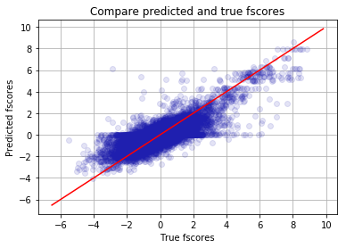

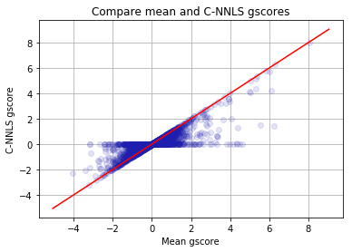

```python
plot_nnls_regression(m133, feba_n, 'IT001', show_fscores=True, show_gscores = True)
```

### Load fscores

```python
fscores = build_fscores(barcode2index, feba_n, 'IT001')
```

# `Elastic Net`

The objective function:

1 / (2 * n_samples) * ||y - Xw||^2_2 + alpha * l1_ratio * ||w||_1 + 0.5 * alpha * (1 - l1_ratio) * ||w||^2_2

- l1_ratio = 1 => Lasso
- l1_ratio = 0 => Ridge

alpha is a parameter that defines the shrinkage, but, the way it is defined, its effect also depeneds on the n_samples.

Let us define r_alpha = 2 * n_smaples * alpha, that do not depened on the number of samples

## 3-fold cross validation

```
Optimal params: r_alpha=4.2; l1_ratio=0.5; alpha=7.63482265852e-05
```

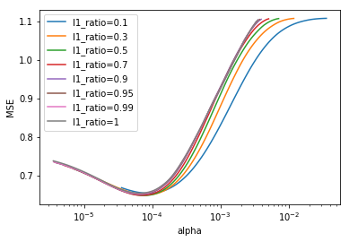

```python
do_enet_cross_validation( m133, fscores, cv=3  )
```

### Observation

It looks good, as expected: on the left side it is overfitting (will be OLS when alpha = 0), on the right side it is underfitting (huge shrinkage), and there is optimum in the middle

## Let's see how elastic net works with the estimated parameters

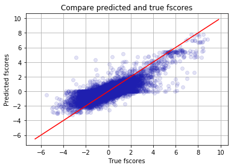

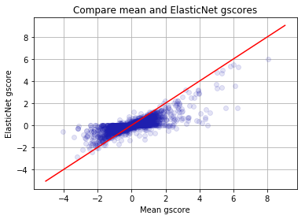

```python
enet = do_enet_regression(m133, fscores, r_alpha=4.2, l1_ratio=0.5, show_fscores=True, show_gscores=True)
```

```python
# Top gene scores
np.sort(enet.coef_)[-5:]
```

```
array([ 4.97092703,  5.26558121,  5.37842994,  5.47797758,  5.96328212])
```

### Conclusion

It seems that the shrinkage is too strong.. Look at the max gscore (it is rcnA gene): we know that it should be around 8 (based on both mean score and nnls), but elastic net with "optimal" parameters gives us 5.96.

#### Why?

Possible reasons:

1. Most of the fscores are around zero, and thus ElasticNetCV optimizes parameters the way to treat well these most abundant "close to zero" values, and thus srhinks too hard... but the most interesting scores are > 2..
2. Our matrix is very sparse. When we do 3-fold cross validation, we remove 1/3 of samples (fragments, fscores), and try to predict features (gene scores). But becuase of sparcity, it might happen that after removing these samples and because of saprsity, genes will not have even a single covering fragment. In this case the predicted score will be zero, and it may introduce some bias.

## Too strong shrinkage: Solution 1

Do corss validation ONLY for thouse genes that have at least one covering framgent with fscore > 2

```
Number of selected genes = 703
Number of selected fragments = 4606
Optimal params: r_alpha=4.7; l1_ratio=0.9; alpha=0.000513965291358
```

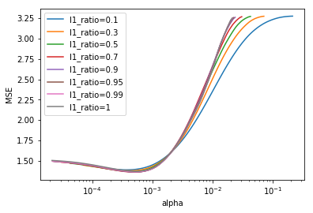

```python
# Max fscore for each gene
g_max = (m133.T*fscores).max(axis=1)

# indices of genes with max fscore > 2
gi = np.nonzero( g_max > 2 )[0]
print('Number of selected genes = %s'% len(gi))

# indicies of fragments covering at least one gene defined by "gi"
fi = np.nonzero( m133[:,gi].sum(axis = 1) > 0 )[0]
print('Number of selected fragments = %s'% len(fi))

# do cross validation for sub matrix
do_enet_cross_validation( m133[:,gi][fi,:], fscores[fi] , cv=3 )
```

### Observation

r-alpha (and alpha) did not change a lot. Actually it is even slighlty increased, it was 4.2, but now 4.7. It might lead to even stronger shrinkage. But the optimal l1_ratio chagned a lot. It was 0.5, but now it is 0.9

Thus, the more l1_ratio, the less influence of L2 component (Ridge), and thus we should expect the less shrinkage. Let us see how ElasticNet will work on the full dataset with r_alpha=4.7 and l1_ratio=0.9

## Let's see how elastic net works with the estimated parameters

r_alpha=4.7, l1_ratio=0.90

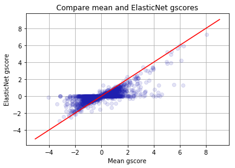

```python
enet = do_enet_regression(m133, fscores, r_alpha=4.7, l1_ratio=0.9)
```

```python
# Top gene scores
np.sort(enet.coef_)[-5:]
```

```
array([ 5.25924184,  5.61521946,  5.9055471 ,  5.99295865,  7.28990361])
```

### Observation

Shrinkage is better, not as strong as it was before. rcnA gene score is 7.3

## Too strong shrinkage: Solution 2

Let us do corss validation only for those genes that are covered by at least 10 fragments

```
Number of selected genes = 1916
Number of selected fragments = 15644
Optimal params: r_alpha=4.3; l1_ratio=0.7; alpha=0.000137258496009
```

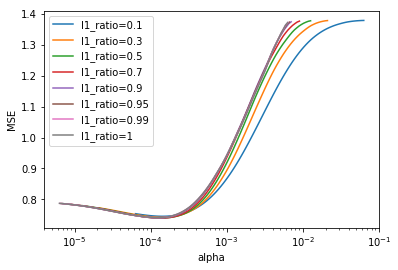

```python
# indices of genes with number of fragments > 10
gi = np.nonzero( m133.T.sum(axis=1) > 10 )[0]
print('Number of selected genes = %s'% len(gi))

# indicies of fragments covering at least one gene defined by "gi"
fi = np.nonzero( m133[:,gi].sum(axis = 1) > 0 )[0]
print('Number of selected fragments = %s'% len(fi))

# do cross validation for sub matrix
do_enet_cross_validation( m133[:,gi][fi,:], fscores[fi], cv=3  )
```

## Let's see how elastic net works with the estimated parameters

r_alpha=4.3; l1_ratio=0.7

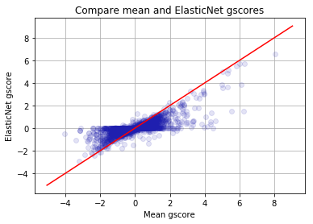

```python
enet = do_enet_regression(m133, fscores, r_alpha=4.3, l1_ratio=0.7)
```

```python
# Top gene scores
np.sort(enet.coef_)[-5:]
```

```
array([ 5.10925413,  5.50820501,  5.67561327,  5.71341572,  6.58352017])
```

### Observation

Shrinkage is still too strong. rcnA gene score is 6.58

## Combine solution 1 and 2

Let us do corss validation only for those genes that are covered by at least 10 fragments and has at least fragment with score > 2

```
Number of selected genes = 390
Number of selected fragments = 3601
Optimal params: r_alpha=5.1; l1_ratio=0.9; alpha=0.000704916431717
```

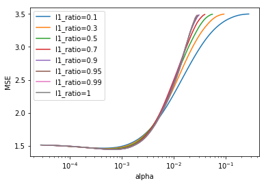

```python
# Max fscore for each gene
g_max = (m133.T*fscores).max(axis=1)

# indices of genes with max fscore > 2 and number of fragments > 10
gi1 = np.nonzero( g_max > 2 )[0]
gi2 = np.nonzero( m133.T.sum(axis=1) > 10 )[0]
gi = np.intersect1d(gi1, gi2)
print('Number of selected genes = %s'% len(gi))

# indicies of fragments covering at least one gene defined by "gi"
fi = np.nonzero( m133[:,gi].sum(axis = 1) > 0 )[0]
print('Number of selected fragments = %s'% len(fi))

# do cross validation for sub matrix
do_enet_cross_validation( m133[:,gi][fi,:], fscores[fi] , cv=3 )
```

### Observation

It is worse than Solution 1 alone: r_alpha is increased (5.1 vs 4.7)

## Distribution of optimal r_alpha and l1_ratio across all conditions

Let us do 3-fold cross validation across all conditions and see the distribution of optimal r_alpha and l1_ratio.

#### We will consider only those genes that have at least one fragment with score > 2

```python
enetSetCV_mfs2  = do_enet_set_cv(['FEBA_133', 'FEBA_134', 'FEBA_136'], min_fscore=2)
```

[output not shown]

[output cut: 411 more lines]

```
	do min fscore
	do cv
Doing [151] FEBA_136: IT071
	do min fscore
	do cv
Doing [152] FEBA_136: IT072
	do min fscore
	do cv
Doing [153] FEBA_136: IT073
	do min fscore
	do cv
Doing [154] FEBA_136: IT074
	do min fscore
	do cv
Done!
```

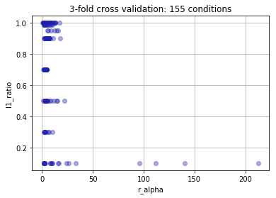

```python
plt.plot(enetSetCV_mfs2.r_alpha, enetSetCV_mfs2.l1_ratio, 'o', color='#1F1FAF5F')
plt.grid(True)
plt.title( '3-fold cross validation: %s conditions' %len(enetSetCV_mfs2.itnum) )
plt.xlabel('r_alpha')
plt.ylabel('l1_ratio')
plt.show()
```

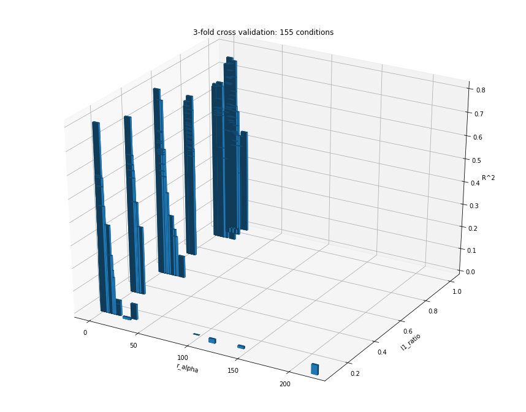

```python
fig = plt.figure( figsize=(15, 12) )
ax = fig.add_subplot(111, projection='3d')
x_data = enetSetCV_mfs2.r_alpha
y_data = enetSetCV_mfs2.l1_ratio
z_data = enetSetCV_mfs2.score_r2
ax.bar3d(
        x_data,
        y_data,
        np.zeros(len(z_data)),
        max(x_data)/7/5,
        max(y_data)/7/15,
        z_data
        )
ax.set_xlabel('r_alpha')
ax.set_ylabel('l1_ratio')
ax.set_zlabel('R^2')
plt.title('3-fold cross validation: %s conditions' %len(enetSetCV_mfs2.itnum) )
plt.show()
```

```python
d = enetSetCV_mfs2
d[d.gcount > 1000].sort_values('score_r2', ascending=False).head(10)
```

|  | score_r2 | gcount | fcount | itnum | alpha | r_alpha | l1_ratio |
| --- | --- | --- | --- | --- | --- | --- | --- |
| 23 | 0.527402 | 1292 | 8604 | FEBA_133:IT024 | 0.000503 | 8.658370 | 0.95 |
| 3 | 0.442203 | 1992 | 12582 | FEBA_133:IT004 | 0.000337 | 8.472769 | 0.99 |
| 83 | 0.433528 | 1085 | 7110 | FEBA_134:IT088 | 0.000366 | 5.211064 | 0.50 |
| 66 | 0.361586 | 1137 | 7876 | FEBA_134:IT071 | 0.000674 | 10.612466 | 0.90 |
| 72 | 0.282290 | 1481 | 10565 | FEBA_134:IT077 | 0.000740 | 15.636363 | 0.95 |
| 30 | 0.277023 | 2045 | 13495 | FEBA_133:IT031 | 0.000541 | 14.602885 | 0.95 |
| 90 | 0.134749 | 1331 | 9180 | FEBA_136:IT007 | 0.000984 | 18.061116 | 0.90 |
| 12 | 0.095668 | 3253 | 19308 | FEBA_133:IT013 | 0.000577 | 22.271351 | 0.50 |

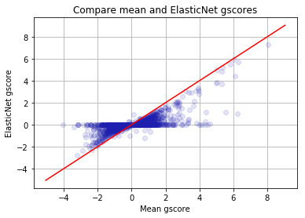

```
ElasticNet(alpha=0.00015584941320469437, copy_X=True, fit_intercept=False,
      l1_ratio=0.95, max_iter=1000, normalize=False, positive=False,
      precompute=False, random_state=None, selection='cyclic', tol=0.0001,
      warm_start=False)
```

```python
do_enet_regression(m133,fscores, r_alpha=8.658370, l1_ratio=0.95)
```

```python
d = enetSetCV_mfs2
d[d.score_r2 > 0.4].sort_values('gcount', ascending=False).head(10)
```

|  | score_r2 | gcount | fcount | itnum | alpha | r_alpha | l1_ratio |
| --- | --- | --- | --- | --- | --- | --- | --- |
| 3 | 0.442203 | 1992 | 12582 | FEBA_133:IT004 | 0.000337 | 8.472769 | 0.99 |
| 23 | 0.527402 | 1292 | 8604 | FEBA_133:IT024 | 0.000503 | 8.658370 | 0.95 |
| 83 | 0.433528 | 1085 | 7110 | FEBA_134:IT088 | 0.000366 | 5.211064 | 0.50 |
| 1 | 0.474586 | 925 | 6453 | FEBA_133:IT002 | 0.000765 | 9.868564 | 0.99 |
| 82 | 0.464617 | 838 | 5637 | FEBA_134:IT087 | 0.000541 | 6.094527 | 0.95 |
| 120 | 0.578547 | 826 | 5254 | FEBA_136:IT040 | 0.000608 | 6.384093 | 0.90 |
| 18 | 0.426625 | 819 | 5955 | FEBA_133:IT019 | 0.001104 | 13.145459 | 1.00 |
| 143 | 0.583772 | 814 | 5244 | FEBA_136:IT063 | 0.000508 | 5.328247 | 0.90 |
| 41 | 0.402871 | 787 | 5286 | FEBA_133:IT042 | 0.000550 | 5.812567 | 0.30 |
| 40 | 0.498481 | 747 | 4848 | FEBA_133:IT041 | 0.000427 | 4.136051 | 0.70 |

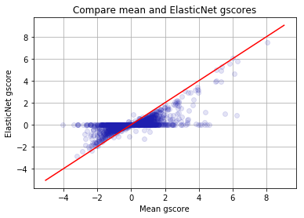

```
ElasticNet(alpha=0.00015250862193102454, copy_X=True, fit_intercept=False,
      l1_ratio=0.99, max_iter=1000, normalize=False, positive=False,
      precompute=False, random_state=None, selection='cyclic', tol=0.0001,
      warm_start=False)
```

```python
do_enet_regression(m133,fscores, r_alpha=8.472769, l1_ratio=0.99)
```

#### We will consider only those genes which are covered by more than 10 fragments

```python
enetSetCV_mfc10 = do_enet_set_cv(['FEBA_133', 'FEBA_134', 'FEBA_136'], min_fcount=10)
```

[output not shown]

[output cut: 411 more lines]

```
	do min fcount
	do cv
Doing [151] FEBA_136: IT071
	do min fcount
	do cv
Doing [152] FEBA_136: IT072
	do min fcount
	do cv
Doing [153] FEBA_136: IT073
	do min fcount
	do cv
Doing [154] FEBA_136: IT074
	do min fcount
	do cv
Done!
```

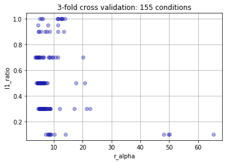

```python
plt.plot(enetSetCV_mfc10.r_alpha, enetSetCV_mfc10.l1_ratio, 'o', color='#1F1FAF5F')
plt.grid(True)
plt.title( '3-fold cross validation: %s conditions' %len(enetSetCV_mfc10.itnum) )
plt.xlabel('r_alpha')
plt.ylabel('l1_ratio')
plt.show()
```

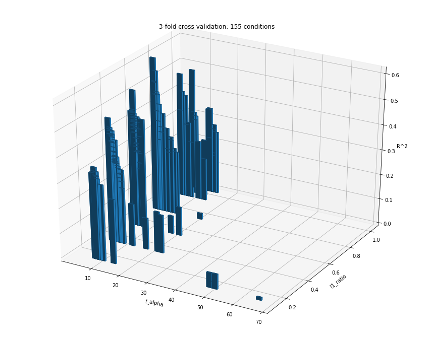

```python
fig = plt.figure( figsize=(15, 12) )
ax = fig.add_subplot(111, projection='3d')
x_data = enetSetCV_mfc10.r_alpha
y_data = enetSetCV_mfc10.l1_ratio
z_data = enetSetCV_mfc10.score_r2
ax.bar3d(
        x_data,
        y_data,
        np.zeros(len(z_data)),
        max(x_data)/7/5,
        max(y_data)/7/15,
        z_data
        )
ax.set_xlabel('r_alpha')
ax.set_ylabel('l1_ratio')
ax.set_zlabel('R^2')
plt.title('3-fold cross validation: %s conditions' %len(enetSetCV_mfc10.itnum) )
plt.show()
```

```python
enetSetCV_mfc10.sort_values('score_r2', ascending=False).head(10)
```

|  | score_r2 | gcount | fcount | itnum | alpha | r_alpha | l1_ratio |
| --- | --- | --- | --- | --- | --- | --- | --- |
| 44 | 0.613119 | 1960 | 16015 | FEBA_134:IT049 | 0.000113 | 3.616342 | 0.7 |
| 0 | 0.563795 | 1916 | 15644 | FEBA_133:IT001 | 0.000137 | 4.294544 | 0.7 |
| 105 | 0.544790 | 1872 | 15274 | FEBA_136:IT025 | 0.000156 | 4.757553 | 0.5 |
| 151 | 0.521847 | 1872 | 15274 | FEBA_136:IT071 | 0.000128 | 3.922791 | 0.7 |
| 128 | 0.517696 | 1872 | 15274 | FEBA_136:IT048 | 0.000128 | 3.914800 | 0.7 |
| 120 | 0.498451 | 1872 | 15274 | FEBA_136:IT040 | 0.000158 | 4.829332 | 0.9 |
| 103 | 0.493201 | 1872 | 15274 | FEBA_136:IT023 | 0.000151 | 4.613954 | 0.3 |
| 143 | 0.487707 | 1872 | 15274 | FEBA_136:IT063 | 0.000168 | 5.141974 | 1.0 |
| 57 | 0.482125 | 1960 | 16015 | FEBA_134:IT062 | 0.000146 | 4.670480 | 0.7 |
| 67 | 0.473348 | 1960 | 16015 | FEBA_134:IT072 | 0.000152 | 4.875842 | 0.7 |

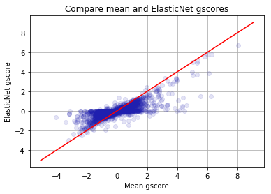

```
ElasticNet(alpha=6.509363525091798e-05, copy_X=True, fit_intercept=False,
      l1_ratio=0.7, max_iter=1000, normalize=False, positive=False,
      precompute=False, random_state=None, selection='cyclic', tol=0.0001,
      warm_start=False)
```

```python
do_enet_regression(m133,fscores, r_alpha=3.616342, l1_ratio=0.7)
```

#### Combined

only those genes which are covered by more than 10 fragments  
and  
only those genes that have at least one fragment with score > 2

```python
enetSetCV_mfc10_mfs2  = do_enet_set_cv(['FEBA_133', 'FEBA_134', 'FEBA_136'], min_fscore=2,  min_fcount=10)
```

[output not shown]

[output cut: 566 more lines]

```
	do min fcount
	do cv
Doing [152] FEBA_136: IT072
	do min fscore
	do min fcount
	do cv
Doing [153] FEBA_136: IT073
	do min fscore
	do min fcount
	do cv
Doing [154] FEBA_136: IT074
	do min fscore
	do min fcount
	do cv
Done!
```

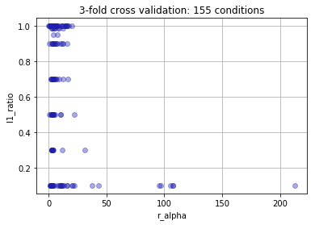

```python
plt.plot(enetSetCV_mfc10_mfs2.r_alpha, enetSetCV_mfc10_mfs2.l1_ratio, 'o', color='#1F1FAF5F')
plt.grid(True)
plt.title( '3-fold cross validation: %s conditions' %len(enetSetCV_mfc10_mfs2.itnum) )
plt.xlabel('r_alpha')
plt.ylabel('l1_ratio')
plt.show()
```

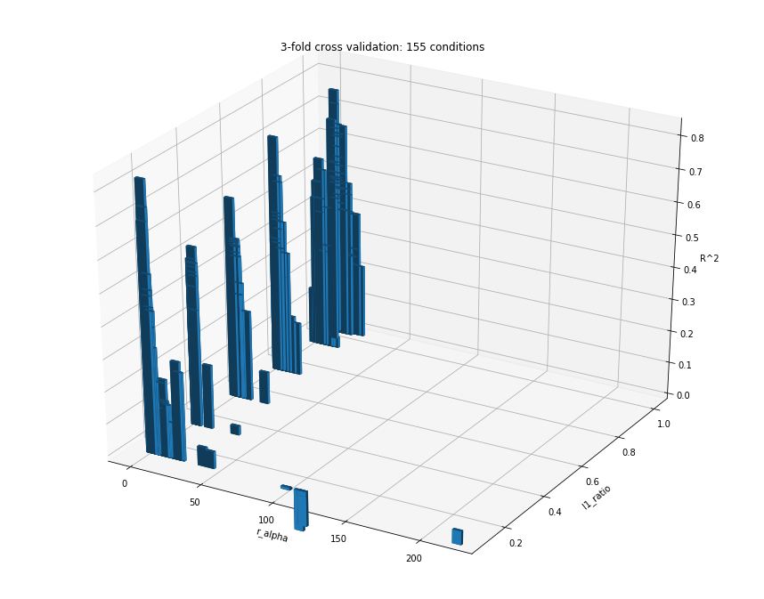

```python
fig = plt.figure( figsize=(15, 12) )
ax = fig.add_subplot(111, projection='3d')
x_data = enetSetCV_mfc10_mfs2.r_alpha
y_data = enetSetCV_mfc10_mfs2.l1_ratio
z_data = enetSetCV_mfc10_mfs2.score_r2
ax.bar3d(
        x_data,
        y_data,
        np.zeros(len(z_data)),
        max(x_data)/7/5,
        max(y_data)/7/15,
        z_data
        )
ax.set_xlabel('r_alpha')
ax.set_ylabel('l1_ratio')
ax.set_zlabel('R^2')
plt.title('3-fold cross validation: %s conditions' %len(enetSetCV_mfc10_mfs2.itnum) )
plt.show()
```

```python
d = enetSetCV_mfc10_mfs2
d[(d.score_r2 > 0.4)].sort_values('gcount', ascending=False).head(10)
```

|  | score_r2 | gcount | fcount | itnum | alpha | r_alpha | l1_ratio |
| --- | --- | --- | --- | --- | --- | --- | --- |
| 1 | 0.481989 | 532 | 5013 | FEBA_133:IT002 | 0.001120 | 11.232986 | 1.00 |
| 82 | 0.424964 | 500 | 4570 | FEBA_134:IT087 | 0.000571 | 5.218095 | 0.90 |
| 120 | 0.494836 | 451 | 4103 | FEBA_136:IT040 | 0.000609 | 4.997302 | 1.00 |
| 40 | 0.449828 | 438 | 3847 | FEBA_133:IT041 | 0.000538 | 4.136051 | 0.70 |
| 143 | 0.486719 | 436 | 4014 | FEBA_136:IT063 | 0.000641 | 5.141974 | 1.00 |
| 44 | 0.613963 | 396 | 3667 | FEBA_134:IT049 | 0.000567 | 4.157915 | 0.70 |
| 0 | 0.591093 | 390 | 3601 | FEBA_133:IT001 | 0.000705 | 5.076808 | 0.90 |
| 29 | 0.444780 | 337 | 2886 | FEBA_133:IT030 | 0.000577 | 3.330232 | 0.50 |
| 49 | 0.463341 | 316 | 3073 | FEBA_134:IT054 | 0.001750 | 10.756567 | 1.00 |
| 10 | 0.452787 | 314 | 3082 | FEBA_133:IT011 | 0.002069 | 12.753906 | 0.99 |

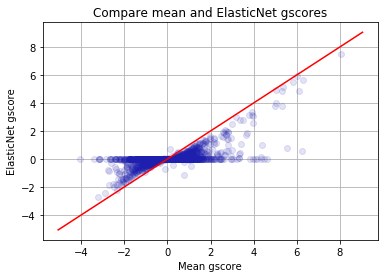

```
ElasticNet(alpha=0.0002021921304629563, copy_X=True, fit_intercept=False,
      l1_ratio=1.0, max_iter=1000, normalize=False, positive=False,
      precompute=False, random_state=None, selection='cyclic', tol=0.0001,
      warm_start=False)
```

```python
do_enet_regression(m133,fscores, r_alpha=11.232986, l1_ratio=1.00)
```

```python
d = enetSetCV_mfc10_mfs2
d[(d.gcount > 100)].sort_values('score_r2', ascending=False).head(10)
```

|  | score_r2 | gcount | fcount | itnum | alpha | r_alpha | l1_ratio |
| --- | --- | --- | --- | --- | --- | --- | --- |
| 44 | 0.613963 | 396 | 3667 | FEBA_134:IT049 | 0.000567 | 4.157915 | 0.7 |
| 0 | 0.591093 | 390 | 3601 | FEBA_133:IT001 | 0.000705 | 5.076808 | 0.9 |
| 145 | 0.558734 | 106 | 951 | FEBA_136:IT065 | 0.002636 | 5.013692 | 1.0 |
| 122 | 0.532221 | 117 | 997 | FEBA_136:IT042 | 0.002872 | 5.727572 | 1.0 |
| 57 | 0.518402 | 233 | 2045 | FEBA_134:IT062 | 0.000888 | 3.632596 | 0.9 |
| 86 | 0.517740 | 120 | 1157 | FEBA_134:IT091 | 0.001155 | 2.673782 | 0.3 |
| 61 | 0.507435 | 142 | 1314 | FEBA_134:IT066 | 0.001128 | 2.963319 | 0.3 |
| 59 | 0.506501 | 108 | 964 | FEBA_134:IT064 | 0.002045 | 3.943312 | 0.3 |
| 58 | 0.498604 | 139 | 1298 | FEBA_134:IT063 | 0.001254 | 3.256161 | 0.5 |
| 32 | 0.498306 | 192 | 1796 | FEBA_133:IT033 | 0.000934 | 3.355153 | 0.7 |

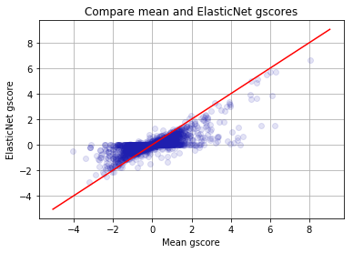

```
ElasticNet(alpha=7.484187126502989e-05, copy_X=True, fit_intercept=False,
      l1_ratio=0.7, max_iter=1000, normalize=False, positive=False,
      precompute=False, random_state=None, selection='cyclic', tol=0.0001,
      warm_start=False)
```

```python
do_enet_regression(m133,fscores, r_alpha=4.157915, l1_ratio=0.7)
```

#### No constrinats, all genes

```python
enetSetCV = do_enet_set_cv(['FEBA_133', 'FEBA_134', 'FEBA_136'])
```

[output not shown]

[output cut: 256 more lines]

```
Doing [148] FEBA_136: IT068
	do cv
Doing [149] FEBA_136: IT069
	do cv
Doing [150] FEBA_136: IT070
	do cv
Doing [151] FEBA_136: IT071
	do cv
Doing [152] FEBA_136: IT072
	do cv
Doing [153] FEBA_136: IT073
	do cv
Doing [154] FEBA_136: IT074
	do cv
Done!
```

```python
enetSetCV.sort_values('score_r2', ascending=False).head(10)
```

|  | score_r2 | gcount | fcount | itnum | alpha | r_alpha | l1_ratio |
| --- | --- | --- | --- | --- | --- | --- | --- |
| 44 | 0.604449 | 4509 | 28094 | FEBA_134:IT049 | 0.000068 | 3.829883 | 0.5 |
| 105 | 0.588367 | 4509 | 27511 | FEBA_136:IT025 | 0.000070 | 3.858998 | 0.5 |
| 0 | 0.546363 | 4509 | 27778 | FEBA_133:IT001 | 0.000076 | 4.241602 | 0.5 |
| 151 | 0.539237 | 4509 | 27511 | FEBA_136:IT071 | 0.000070 | 3.874432 | 0.5 |
| 128 | 0.525153 | 4509 | 27511 | FEBA_136:IT048 | 0.000075 | 4.145964 | 0.5 |
| 103 | 0.515352 | 4509 | 27511 | FEBA_136:IT023 | 0.000084 | 4.613954 | 0.3 |
| 57 | 0.514194 | 4509 | 28094 | FEBA_134:IT062 | 0.000067 | 3.788371 | 0.7 |
| 67 | 0.503874 | 4509 | 28094 | FEBA_134:IT072 | 0.000087 | 4.875842 | 0.7 |
| 24 | 0.498423 | 4509 | 27778 | FEBA_133:IT025 | 0.000085 | 4.716795 | 0.5 |
| 143 | 0.498106 | 4509 | 27511 | FEBA_136:IT063 | 0.000097 | 5.328247 | 0.9 |

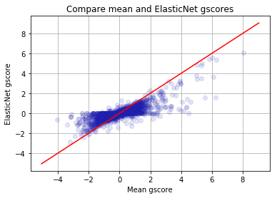

```
ElasticNet(alpha=6.893734250125999e-05, copy_X=True, fit_intercept=False,
      l1_ratio=0.5, max_iter=1000, normalize=False, positive=False,
      precompute=False, random_state=None, selection='cyclic', tol=0.0001,
      warm_start=False)
```

```python
do_enet_regression(m133,fscores, r_alpha=3.829883, l1_ratio=0.5)
```

## Combine all conditions into one model and do cross-validation

Let us do 3-fold cross validation for all conditions combined together to find "universal" optimal r_alpha and l1_ratio.

#### We will consider only those genes which are covered by more than 10 fragments

```python
enetcv_mfc10 = do_enet_combined(['FEBA_133', 'FEBA_134', 'FEBA_136'], min_fcount=10)
```

```
Doing[0] FEBA_133: IT001
	do min fcount
	f_offset=15644; g_offset=1916; m_elems=27890
Doing[1] FEBA_133: IT002
	do min fcount
	f_offset=31288; g_offset=3832; m_elems=55780
Doing[2] FEBA_133: IT003
	do min fcount
	f_offset=46932; g_offset=5748; m_elems=83670
Doing[3] FEBA_133: IT004
	do min fcount
	f_offset=62576; g_offset=7664; m_elems=111560
Doing[4] FEBA_133: IT005
	do min fcount
	f_offset=78220; g_offset=9580; m_elems=139450
Doing[5] FEBA_133: IT006
	do min fcount
	f_offset=93864; g_offset=11496; m_elems=167340
Doing[6] FEBA_133: IT007
	do min fcount
	f_offset=109508; g_offset=13412; m_elems=195230
Doing[7] FEBA_133: IT008
	do min fcount
	f_offset=125152; g_offset=15328; m_elems=223120
Doing[8] FEBA_133: IT009
	do min fcount
	f_offset=140796; g_offset=17244; m_elems=251010
Doing[9] FEBA_133: IT010
	do min fcount
	f_offset=156440; g_offset=19160; m_elems=278900
Doing[10] FEBA_133: IT011
	do min fcount
	f_offset=172084; g_offset=21076; m_elems=306790
Doing[11] FEBA_133: IT012
	do min fcount
	f_offset=187728; g_offset=22992; m_elems=334680
Doing[12] FEBA_133: IT013
	do min fcount
	f_offset=203372; g_offset=24908; m_elems=362570
Doing[13] FEBA_133: IT014
```

[output cut: 414 more lines]

```
	do min fcount
	f_offset=2369791; g_offset=290264; m_elems=4228056
Doing[152] FEBA_136: IT072
	do min fcount
	f_offset=2385065; g_offset=292136; m_elems=4255256
Doing[153] FEBA_136: IT073
	do min fcount
	f_offset=2400339; g_offset=294008; m_elems=4282456
Doing[154] FEBA_136: IT074
	do min fcount
	f_offset=2415613; g_offset=295880; m_elems=4309656
Converting sparse matrix..
matrix shape=(2415613, 295880); fvalues=2415613
Doing corss validation...
Done!
```

```python
enetcv_mfc10
```

|  | alpha | l1_ratio | r_alpha | score_r2 | fcount | gcount |
| --- | --- | --- | --- | --- | --- | --- |
| 0 | 0.000002 | 0.5 | 8.099557 | 0.352298 | 2415613 | 295880 |

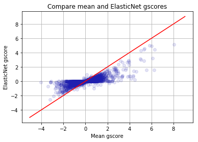

```
ElasticNet(alpha=0.00014579085967312262, copy_X=True, fit_intercept=False,
      l1_ratio=0.5, max_iter=1000, normalize=False, positive=False,
      precompute=False, random_state=None, selection='cyclic', tol=0.0001,
      warm_start=False)
```

```python
do_enet_regression(m133,fscores, r_alpha=8.099557, l1_ratio=0.5)
```

#### We will consider only those genes that have at least one fragment with score > 2

```python
enetcv_mfs2 = do_enet_combined(['FEBA_133', 'FEBA_134', 'FEBA_136'], min_fscore=2)
```

```
Doing[0] FEBA_133: IT001
	do min fscore
	f_offset=4606; g_offset=703; m_elems=8073
Doing[1] FEBA_133: IT002
	do min fscore
	f_offset=11059; g_offset=1628; m_elems=18881
Doing[2] FEBA_133: IT003
	do min fscore
	f_offset=17478; g_offset=2523; m_elems=29508
Doing[3] FEBA_133: IT004
	do min fscore
	f_offset=30060; g_offset=4515; m_elems=51394
Doing[4] FEBA_133: IT005
	do min fscore
	f_offset=31211; g_offset=4676; m_elems=53316
Doing[5] FEBA_133: IT006
	do min fscore
	f_offset=31947; g_offset=4783; m_elems=54704
Doing[6] FEBA_133: IT007
	do min fscore
	f_offset=32139; g_offset=4810; m_elems=55059
Doing[7] FEBA_133: IT008
	do min fscore
	f_offset=33277; g_offset=4962; m_elems=56833
Doing[8] FEBA_133: IT009
	do min fscore
	f_offset=37942; g_offset=5597; m_elems=64469
Doing[9] FEBA_133: IT010
	do min fscore
	f_offset=38667; g_offset=5690; m_elems=65630
Doing[10] FEBA_133: IT011
	do min fscore
	f_offset=42527; g_offset=6207; m_elems=71932
Doing[11] FEBA_133: IT012
	do min fscore
	f_offset=42574; g_offset=6210; m_elems=71990
Doing[12] FEBA_133: IT013
	do min fscore
	f_offset=61882; g_offset=9463; m_elems=108477
Doing[13] FEBA_133: IT014
```

[output cut: 414 more lines]

```
	do min fscore
	f_offset=317194; g_offset=46117; m_elems=544550
Doing[152] FEBA_136: IT072
	do min fscore
	f_offset=317308; g_offset=46130; m_elems=544716
Doing[153] FEBA_136: IT073
	do min fscore
	f_offset=317447; g_offset=46144; m_elems=544956
Doing[154] FEBA_136: IT074
	do min fscore
	f_offset=317570; g_offset=46167; m_elems=545181
Converting sparse matrix..
matrix shape=(317570, 46167); fvalues=317570
Doing corss validation...
Done!
```

```python
enetcv_mfs2
```

|  | alpha | l1_ratio | r_alpha | score_r2 | fcount | gcount |
| --- | --- | --- | --- | --- | --- | --- |
| 0 | 0.000017 | 0.99 | 10.865219 | 0.364089 | 317570 | 46167 |

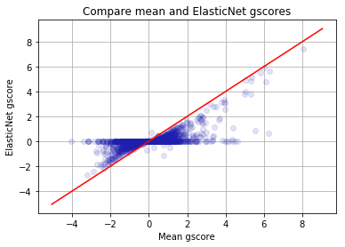

```
ElasticNet(alpha=0.00019557237742098062, copy_X=True, fit_intercept=False,
      l1_ratio=0.99, max_iter=1000, normalize=False, positive=False,
      precompute=False, random_state=None, selection='cyclic', tol=0.0001,
      warm_start=False)
```

```python
do_enet_regression(m133,fscores, r_alpha=10.865219, l1_ratio=0.99)
```

#### Combined

only those genes which are covered by more than 10 fragments  
and  
only those genes that have at least one fragment with score > 2

```python
enetcv_mfs2_mfc10 = do_enet_combined(['FEBA_133', 'FEBA_134', 'FEBA_136'], min_fscore=2, min_fcount=10)
```

```
Doing[0] FEBA_133: IT001
	do min fscore
	do min fcount
	f_offset=3601; g_offset=390; m_elems=5822
Doing[1] FEBA_133: IT002
	do min fscore
	do min fcount
	f_offset=8614; g_offset=922; m_elems=13790
Doing[2] FEBA_133: IT003
	do min fscore
	do min fcount
	f_offset=13708; g_offset=1462; m_elems=21827
Doing[3] FEBA_133: IT004
	do min fscore
	do min fcount
	f_offset=23250; g_offset=2502; m_elems=37129
Doing[4] FEBA_133: IT005
	do min fscore
	do min fcount
	f_offset=24100; g_offset=2588; m_elems=38518
Doing[5] FEBA_133: IT006
	do min fscore
	do min fcount
	f_offset=24754; g_offset=2665; m_elems=39706
Doing[6] FEBA_133: IT007
	do min fscore
	do min fcount
	f_offset=24910; g_offset=2682; m_elems=39999
Doing[7] FEBA_133: IT008
	do min fscore
	do min fcount
	f_offset=25804; g_offset=2772; m_elems=41331
Doing[8] FEBA_133: IT009
	do min fscore
	do min fcount
	f_offset=29550; g_offset=3147; m_elems=47092
Doing[9] FEBA_133: IT010
	do min fscore
	do min fcount
	f_offset=30145; g_offset=3205; m_elems=48006
```

[output cut: 569 more lines]

```
	do min fscore
	do min fcount
	f_offset=249965; g_offset=26777; m_elems=406477
Doing[153] FEBA_136: IT073
	do min fscore
	do min fcount
	f_offset=250080; g_offset=26787; m_elems=406685
Doing[154] FEBA_136: IT074
	do min fscore
	do min fcount
	f_offset=250158; g_offset=26795; m_elems=406802
Converting sparse matrix..
matrix shape=(250158, 26795); fvalues=250158
Doing corss validation...
Done!
```

```python
enetcv_mfs2_mfc10
```

|  | alpha | l1_ratio | r_alpha | score_r2 | fcount | gcount |
| --- | --- | --- | --- | --- | --- | --- |
| 0 | 0.000024 | 0.95 | 12.140963 | 0.331209 | 250158 | 26795 |

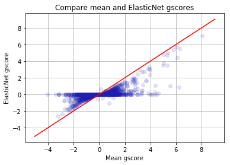

```
ElasticNet(alpha=0.00021853558571531426, copy_X=True, fit_intercept=False,
      l1_ratio=0.95, max_iter=1000, normalize=False, positive=False,
      precompute=False, random_state=None, selection='cyclic', tol=0.0001,
      warm_start=False)
```

```python
do_enet_regression(m133,fscores, r_alpha=12.140963, l1_ratio=0.95)
```

# `Lasso`

The objective function:

(1 / (2 * n_samples)) * ||y - Xw||^2_2 + alpha * ||w||_1

alpha is a parameter that defines the shrinkage, but, the way it is defined, its effect also depeneds on the n_samples.

Let us define r_alpha = 2 * n_smaples * alpha, that do not depened on the number of samples

```python
feba_n = 'FEBA_133'
barcode2index = build_barcode_2_index(feba_n)
fscores = build_fscores(barcode2index, feba_n, 'IT001')
```

## 3-fold cross validation

```
Optimal params: r_alpha=3.7; alpha=6.67103471239e-05
```

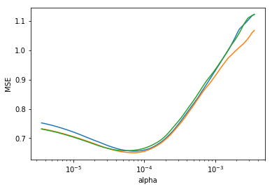

```
LassoCV(alphas=None, copy_X=True, cv=3, eps=0.001, fit_intercept=False,
    max_iter=1000, n_alphas=100, n_jobs=1, normalize=False, positive=False,
    precompute='auto', random_state=None, selection='cyclic', tol=0.0001,
    verbose=False)
```

```python
do_lasso_cross_validation( m133, fscores, cv=3  )
```

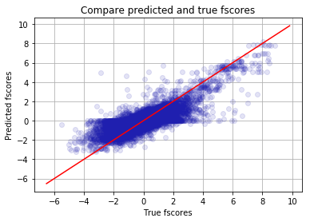

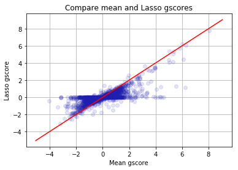

```
Lasso(alpha=6.659946720426237e-05, copy_X=True, fit_intercept=False,
   max_iter=1000, normalize=False, positive=False, precompute=False,
   random_state=None, selection='cyclic', tol=0.0001, warm_start=False)
```

```python
do_lasso_regression(m133, fscores, r_alpha=3.7, show_fscores=True, show_gscores=True)
```

## Distribution of optimal r_alpha across all conditions

```python
lassoSetCV  = do_lasso_set_cv(['FEBA_133', 'FEBA_134', 'FEBA_136'])
```

[output not shown]

[output cut: 256 more lines]

```
Doing [148] FEBA_136: IT068
	do cv
Doing [149] FEBA_136: IT069
	do cv
Doing [150] FEBA_136: IT070
	do cv
Doing [151] FEBA_136: IT071
	do cv
Doing [152] FEBA_136: IT072
	do cv
Doing [153] FEBA_136: IT073
	do cv
Doing [154] FEBA_136: IT074
	do cv
Done!
```

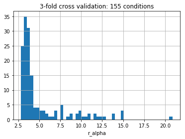

```python
plt.hist(lassoSetCV.r_alpha, bins = 50)
plt.grid(True)
plt.title( '3-fold cross validation: %s conditions' %len(lassoSetCV.itnum) )
plt.xlabel('r_alpha')
plt.show()
```

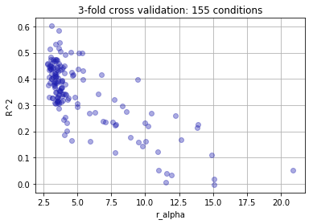

```python
plt.plot(lassoSetCV.r_alpha, lassoSetCV.score_r2, 'o', color='#1F1FAF5F')
plt.grid(True)
plt.title( '3-fold cross validation: %s conditions' %len(lassoSetCV.itnum) )
plt.xlabel('r_alpha')
plt.ylabel('R^2')
plt.show()
```